# Practical Machine Learning - Joe Pogson

Joe Pogson

4/21/2020

## Overview

Using devices such as Jawbone Up, Nike FuelBand, and Fitbit it is now possible to collect a large amount of data about personal activity relatively inexpensively.

These type of devices are part of the quantified self movement – a group of enthusiasts who take measurements about themselves regularly to improve their health, to find patterns in their behavior, or because they are tech geeks.

One thing that people regularly do is quantify how much of a particular activity they do, but they rarely quantify how well they do it. In this project, your goal will be to use data from accelerometers on the belt, forearm, arm, and dumbell of 6 participants. They were asked to perform barbell lifts correctly and incorrectly in 5 different ways.

More information is available from the website here: http://web.archive.org/web/20161224072740/http:/groupware.les.inf.puc-rio.br/har

## Library and Data loading.

```r
library(caret)
library(rattle)
library(e1071)
library(randomForest)
library(gbm)
library(survival)
library(splines)
library(parallel)
library(plyr)
```

```r
TrainData <- read.csv(url("https://d396qusza40orc.cloudfront.net/predmachlearn/pml-training.csv"),header=TRUE)
dim(TrainData)
```

```
## [1] 19622   160
```

```r
TestData <-read.csv(url("https://d396qusza40orc.cloudfront.net/predmachlearn/pml-testing.csv"),header=TRUE)
dim(TestData)
```

```
## [1]  20 160
```

```r
str(TrainData)
```

```
## 'data.frame':    19622 obs. of  160 variables:
##  $ X                       : int  1 2 3 4 5 6 7 8 9 10 ...
##  $ user_name               : Factor w/ 6 levels "adelmo","carlitos",..: 2 2 2 2 2 2 2 2 2 2 ...
##  $ raw_timestamp_part_1    : int  1323084231 1323084231 1323084231 1323084232 1323084232 1323084232 1323084232 1323084232 1323084232 1323084232 ...
##  $ raw_timestamp_part_2    : int  788290 808298 820366 120339 196328 304277 368296 440390 484323 484434 ...
##  $ cvtd_timestamp          : Factor w/ 20 levels "02/12/2011 13:32",..: 9 9 9 9 9 9 9 9 9 9 ...
##  $ new_window              : Factor w/ 2 levels "no","yes": 1 1 1 1 1 1 1 1 1 1 ...
##  $ num_window              : int  11 11 11 12 12 12 12 12 12 12 ...
##  $ roll_belt               : num  1.41 1.41 1.42 1.48 1.48 1.45 1.42 1.42 1.43 1.45 ...
##  $ pitch_belt              : num  8.07 8.07 8.07 8.05 8.07 8.06 8.09 8.13 8.16 8.17 ...
##  $ yaw_belt                : num  -94.4 -94.4 -94.4 -94.4 -94.4 -94.4 -94.4 -94.4 -94.4 -94.4 ...
##  $ total_accel_belt        : int  3 3 3 3 3 3 3 3 3 3 ...
##  $ kurtosis_roll_belt      : Factor w/ 397 levels "","-0.016850",..: 1 1 1 1 1 1 1 1 1 1 ...
##  $ kurtosis_picth_belt     : Factor w/ 317 levels "","-0.021887",..: 1 1 1 1 1 1 1 1 1 1 ...
##  $ kurtosis_yaw_belt       : Factor w/ 2 levels "","#DIV/0!": 1 1 1 1 1 1 1 1 1 1 ...
```

[output cut: 86 more lines]

Here we can see that the data is made up of 160 parameters from 19622 observations. We can remove some of these parameters as they are mainly NAs or are purely personal information not relevant for this model.

## Cleaning Data

```r
removeCol <- which(colSums(is.na(TrainData)|TrainData=="")>0.9*dim(TrainData)[1])
CleanTrainData <- TrainData[,-removeCol]
CleanTrainData <- CleanTrainData[,-(1:5)]
dim(CleanTrainData)
```

```
## [1] 19622    55
```

Repeat for the Test Data.

```r
removeCol <- which(colSums(is.na(TestData)|TestData=="")>0.9*dim(TestData)[1])
CleanTestData <- TestData[,-removeCol]
CleanTestData <- CleanTestData[,-(1:5)]
dim(CleanTestData)
```

```
## [1] 20 55
```

We have now reduced the number of parameters to 55.

## Training

```r
set.seed(12345)
inTrain1 <- createDataPartition(CleanTrainData$classe, p=0.75, list=FALSE)
Train1 <- CleanTrainData[inTrain1,]
Test1 <- CleanTrainData[-inTrain1,]
dim(Train1)
```

```
## [1] 14718    55
```

```r
dim(Test1)
```

```
## [1] 4904   55
```

### Classification tree

First we will test the data using a classification tree,

```r
trControl <- trainControl(method="cv", number=5)
model_CT <- train(classe~., data=Train1, method="rpart", trControl=trControl)
```

[figure not shown]

```r
fancyRpartPlot(model_CT$finalModel)
```

SHow the confusion matrix and accuracy of this model.

```r
PredTrain <- predict(model_CT,newdata = Test1)
ConfMtxCT <- confusionMatrix(Test1$class,PredTrain)
ConfMtxCT$table
```

```
##           Reference
## Prediction    A    B    C    D    E
##          A 1252   30   90    0   23
##          B  396  317  236    0    0
##          C  434   24  397    0    0
##          D  343  151  310    0    0
##          E  114  132  229    0  426
```

```r
ConfMtxCT$overall[1]
```

```
##  Accuracy
## 0.4877651
```

Here we can see that the accuracy for this Model is 49% not a bad start.

### Random forests

Lets try again but with random forests this time.

```r
controlRF <- trainControl(method="cv", number=3, verboseIter=FALSE)
RandFor <- train(classe ~ ., data=Train1, method="rf",
                          trControl=controlRF)
RandFor$finalModel
```

```
##
## Call:
##  randomForest(x = x, y = y, mtry = param$mtry)
##                Type of random forest: classification
##                      Number of trees: 500
## No. of variables tried at each split: 28
##
##         OOB estimate of  error rate: 0.2%
## Confusion matrix:
##      A    B    C    D    E  class.error
## A 4183    1    0    0    1 0.0004778973
## B    5 2839    3    1    0 0.0031601124
## C    0    4 2562    1    0 0.0019477990
## D    0    0    9 2403    0 0.0037313433
## E    0    1    0    4 2701 0.0018477458
```

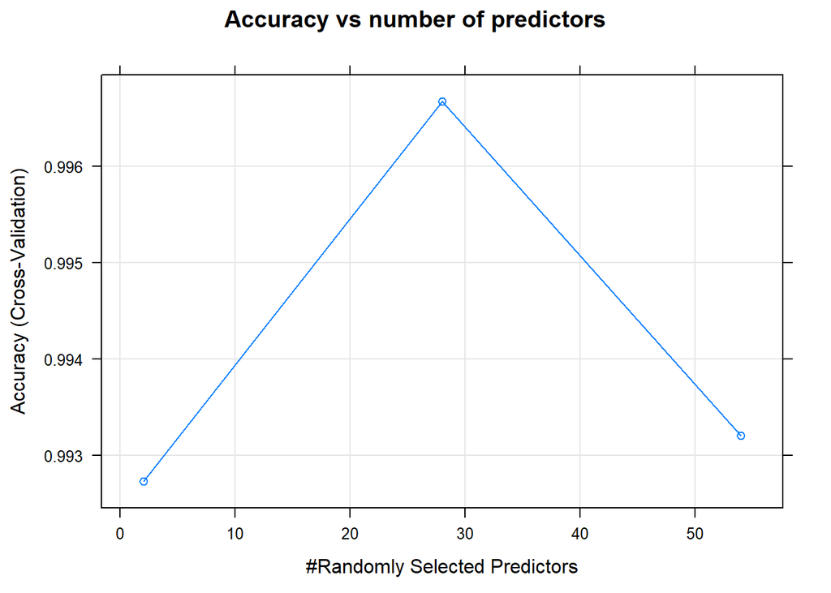

```r
plot(RandFor,main="Accuracy vs number of predictors")
```

```r
trainpred <-predict(RandFor,newdata=Test1)
RFConfMTX <- confusionMatrix(Test1$classe,trainpred)
```

```r
RFConfMTX$overall[1]
```

```
##  Accuracy
## 0.9983687
```

With random forest we have increased our accuracy to almost 100% WOW.

### Generalised Boosted Model

Just to see if we can possibly improve on the random forest method we will use the generalised boosted model.

```r
model_GBM <- train(classe~., data=Train1, method="gbm", trControl=trControl, verbose=FALSE)
```

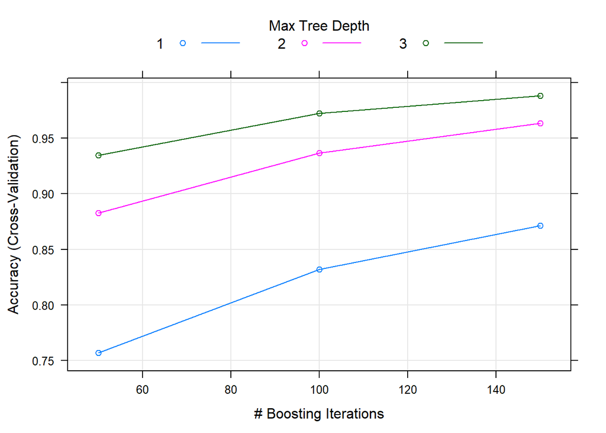

```r
plot(model_GBM)
```

```r
trainpred <- predict(model_GBM,newdata=Test1)

confMatGBM <- confusionMatrix(Test1$classe,trainpred)
confMatGBM$table
```

```
##           Reference
## Prediction    A    B    C    D    E
##          A 1391    4    0    0    0
##          B   10  928   10    1    0
##          C    0    4  850    1    0
##          D    0    1   18  779    6
##          E    0    5    2    4  890
```

```r
confMatGBM$overall[1]
```

```
##  Accuracy
## 0.9865416
```

With 5 folds the precision is 98.6%. Just a bit less than the Random Forest.

## Conculsion

```r
FinalTestPred <- predict(RandFor,newdata=CleanTestData)
FinalTestPred
```

```
##  [1] B A B A A E D B A A B C B A E E A B B B
## Levels: A B C D E
```